# # Exploring White Wine Quality by Ursula Neumann

### Description Two

I chose this graph as it illustrates how alcohol and density (the only 2 variables that were correlated with quality) change with increasing quality. The boxplot allows you to glean information such as the 5 number summary, outliers, overlap between groups, and trends across quality ratings.

### Plot Three

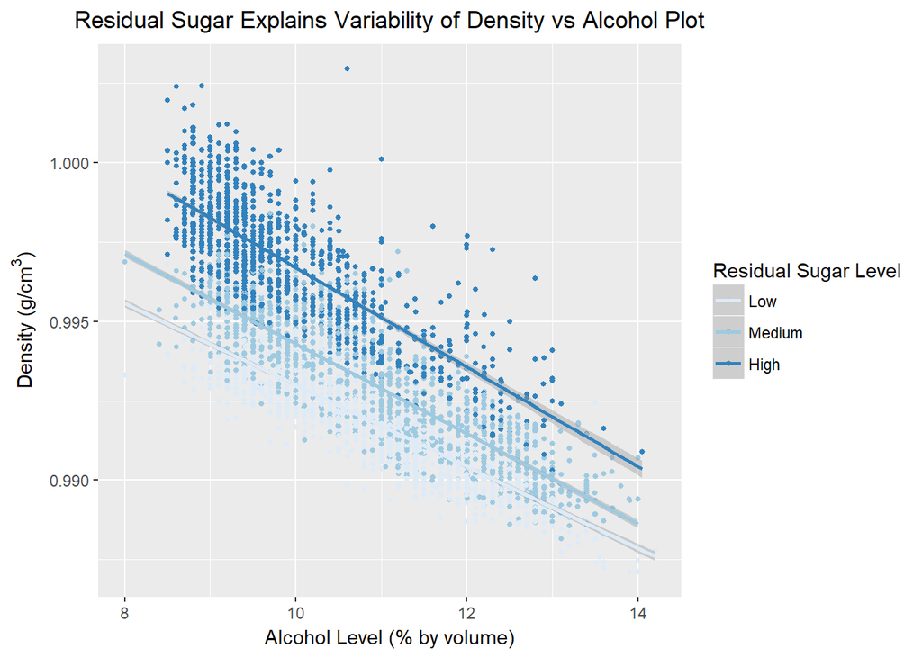

### Description Three

The strongest relationships found were between density vs alcohol (-0.8) and density vs residual sugar (0.8) and this multivariate plot was able to display all three variables at once. It appears that residual sugar levels explain some of the variability in the density vs alcohol plot, and alcohol and residual sugar alone were able to predict density levels with an R-squared value of 0.907.

# Reflection

I found that plotting all the histograms in the univariate plots was tedious, boring, and not very informative since it is not intuitive what all the variables mean, or the significance of the values.

I was disappointed that I wasn’t able to find anything that strongly correlated with the quality of wine, and that the predictive model was so poor. For something like the diamonds dataset, it is more intuitive that you’d be able to predict the price of a diamond - generally, the bigger, the better. However, with wine, quality can be quite subjective, especially for an expert vs a non-expert. Some people love sweet and some people hate it. Some people may be turned off if the alcohol taste is too strong. Some experts might be swayed by hints of flavors and depth of taste while I just hope the wine doesn’t taste like cleaner.

After doing a more in-depth investigation into what dictates density I was a little more excited and willing to complete this project. Although it is obvious that alcohol levels and solutes will affect density, it was fun to play with the predictions using the linear models.

For future analysis, I think it would be interesting if use more complicated modelling techniques to create more accurate predictive models such as those used in this [R Pubs post](http://www.rpubs.com/datascientiest/237448).

# Resources

https://stackoverflow.com/questions/6286313/remove-an-entire-column-from-a-data-frame-in-r https://www.sciencedirect.com/science/article/pii/S0167923609001377 https://s3.amazonaws.com/udacity-hosted-downloads/ud651/wineQualityInfo.txt https://s3.amazonaws.com/content.udacity-data.com/courses/ud651/diamondsExample_2016-05.html http://colorbrewer2.org/#type=sequential&scheme=Blues&n=7 https://stackoverflow.com/questions/40675778/center-plot-title-in-ggplot2 https://stackoverflow.com/questions/35618260/removing-legend-ggplot-2-2 http://www.rpubs.com/datascientiest/237448 https://stackoverflow.com/questions/39709745/decreasing-the-line-thickness-and-corr-font-size-in-ggpairs-plot